# MA5761 - Homework 1

Karthik Garimella

2023-09-03

## Question 1

1. Write an R function, call it t.conf.int, which calculates a confidence interval on a population mean µ using Student’s t distribution. Recall that a 100(1 − α)% confidence interval on µ calculated from a sample x1, x2, . . . , xn takes the form  
   x¯ ± tn−1,α/2 ·s√n  
   where  
   • x¯ is the sample mean  
   • s is the sample standard deviation  
   • n is the sample size  
   • 1 − α is the confidence level of the confidence interval (typically 0.95)  
   • tn−1,α/2  
   is the quantile from Student’s t distribution with n − 1 degrees of freedom that cuts off an upper tail probability of α/2  
   For instance, for a 85% confidence interval constructed from a sample of size n = 20, α = 0.15 and  
   tn−1,α/2 = t19,0.075 ≈ 1.5002.  
   Your function should take two arguments: a numeric vector x, and a confidence level conf.level.  
   There should be a default value of 0.95 to the conf.level argument. Your function should return a named vector, consisting of the elements  
   • lwr.CI, the lower bound in the confidence interval  
   • upr.CI, the upper bound in the confidence interval  
   • mean, the sample mean  
   • err.margin, the margin of error in the confidence interval (tn−1,α/2 · s/(√n)  
   • conf.level, the confidence level 1 − α

```r
#t.conf.int function to find the 95% confidence interval for an x vector input and a confidence level (where the default is 0.95)
t.conf.int = function(x, conf.level = 0.95){

  get_avg = mean(x)
  get_sdev = sd(x)
  n = length(x)
  get_alpha = (1 - conf.level)/2
  get_t_test = qt(get_alpha, n-1, lower.tail = FALSE)

  lwr.CI = get_avg - (get_t_test * get_sdev/sqrt(n))
  upr.CI = get_avg + (get_t_test * get_sdev/sqrt(n))
  get_mean = get_avg
  err.margin = get_t_test * get_sdev/sqrt(n)

 named_vector = setNames(c(lwr.CI, upr.CI, get_mean, err.margin, conf.level),
 c("Lower_CI", "Upper_CI", "Mean", "Error_Margin", "Confidence_Level"))

 named_vector

}

get_random = rnorm(1:10, mean = 50, sd = 15)

get_random
```

```
##  [1] 52.56685 31.77169 35.02368 71.24666 58.91140 40.40817 70.38653 68.62154
##  [9] 35.97227 28.39355
```

```r
t.conf.int(get_random, 0.95)
```

```
##         Lower_CI         Upper_CI             Mean     Error_Margin
##         37.15401         61.50646         49.33023         12.17623
## Confidence_Level
##          0.95000
```

## Question 2

1. Read the documentation on the split function in R, and use this to create a list of the chick weights split by the different levels of feed

```r
head(chickwts)
```

```
##   weight      feed
## 1    179 horsebean
## 2    160 horsebean
## 3    136 horsebean
## 4    227 horsebean
## 5    217 horsebean
## 6    168 horsebean
```

```r
split_list = (split(x = chickwts, f = chickwts$feed)) # splitting the dataset by feed type

is.list(split_list)
```

```
## [1] TRUE
```

```r
split_list
```

```
## $casein
##    weight   feed
## 60    368 casein
## 61    390 casein
## 62    379 casein
## 63    260 casein
## 64    404 casein
## 65    318 casein
## 66    352 casein
## 67    359 casein
## 68    216 casein
## 69    222 casein
## 70    283 casein
## 71    332 casein
##
```

[output cut: 73 more lines]

2. Test out your t.conf.int function on this data by calculating a 95% confidence interval on the mean weight of chicks fed with horsebean. Use the list that you created previously to extract that sample of desired weights.

```r
t.conf.int(c(split_list$horsebean$weight), 0.95)
```

```
##         Lower_CI         Upper_CI             Mean     Error_Margin
##        132.56874        187.83126        160.20000         27.63126
## Confidence_Level
##          0.95000
```

3. Look at the documenation for lapply and sapply functions. Create a set of 95% simultaneous confidence intervals for the mean weight of chicks for the six different groups of feed. The simplest route for this would be to apply the Bonferroni correction: calculate six confidence intervals each using the same confidence level of 100(1 − 0.05/6)% ≈ 99.167%. Do this with both lapply and sapply. Comment on the differences in the output from each function.

```r
head(chickwts)
```

```
##   weight      feed
## 1    179 horsebean
## 2    160 horsebean
## 3    136 horsebean
## 4    227 horsebean
## 5    217 horsebean
## 6    168 horsebean
```

```r
# creating a dataset of mean, standard deviation and count for applying the lapply and sapply function to the chickwts feed types

CI_100 = setNames(aggregate(chickwts$weight, list(chickwts$feed), FUN=mean), c("feed_type","mean_weight"))

CI_200 = setNames(aggregate(chickwts$weight, list(chickwts$feed), FUN=sd), c("feed_type","standard_dev"))

CI_300 = setNames(aggregate(chickwts$weight, list(chickwts$feed), FUN=length), c("feed_type","count"))

CI_9500 = merge(CI_100, CI_200,  by = c("feed_type", "feed_type"))

CI_9500 = merge(CI_9500, CI_300,  by = c("feed_type", "feed_type"))

CI = CI_9500


func_value = function(x, conf.level = 0.95){

  get_avg = as.numeric(as.character(x[2]))
  get_sdev = as.numeric(as.character(x[3]))
  n = as.numeric(as.character(x[4]))
  get_alpha = (1 - conf.level)/2
  get_t_test = qt(get_alpha, n-1, lower.tail = FALSE)



  lwr.CI = get_avg - (get_t_test * get_sdev/sqrt(n))
  upr.CI = get_avg + (get_t_test * get_sdev/sqrt(n))
  get_mean = get_avg
  err.margin = get_t_test * get_sdev/sqrt(n)

  named_vector = setNames(c(x[1],lwr.CI, upr.CI, get_mean, err.margin, conf.level),
                          c("Feed_Type", "Lower_CI", "Upper_CI", "Mean", "Error_Margin", "Confidence_Level"))

  named_vector

}

lapply(1: ncol(t(CI)), function (i) func_value(t(CI[i,]), 0.99167))
```

```
## [[1]]
##          Feed_Type           Lower_CI           Upper_CI               Mean
##           "casein" "263.906607450169" "383.259992549831"         "323.5833"
##       Error_Margin   Confidence_Level
## "59.6766925498306"          "0.99167"
##
## [[2]]
##          Feed_Type           Lower_CI           Upper_CI               Mean
##        "horsebean" "119.104647937438" "201.295352062562"            "160.2"
##       Error_Margin   Confidence_Level
## "41.0953520625622"          "0.99167"
##
## [[3]]
##          Feed_Type           Lower_CI           Upper_CI               Mean
##          "linseed" "170.370859333773" "267.129140666227"           "218.75"
##       Error_Margin   Confidence_Level
## "48.3791406662274"          "0.99167"
##
## [[4]]
##          Feed_Type           Lower_CI           Upper_CI               Mean
##         "meatmeal"  "212.78234838428"  "341.03585161572"         "276.9091"
##       Error_Margin   Confidence_Level
## "64.1267516157204"          "0.99167"
##
## [[5]]
##          Feed_Type           Lower_CI           Upper_CI               Mean
##          "soybean" "201.477513908157" "291.379686091843"         "246.4286"
##       Error_Margin   Confidence_Level
## "44.9510860918426"          "0.99167"
##
## [[6]]
##          Feed_Type           Lower_CI           Upper_CI               Mean
##        "sunflower" "283.685907694176" "374.147492305824"         "328.9167"
##       Error_Margin   Confidence_Level
##  "45.230792305824"          "0.99167"
```

```r
sapply(1: ncol(t(CI)), function (i) func_value(t(CI[i,]), 0.95))
```

```
##                  [,1]               [,2]               [,3]
## Feed_Type        "casein"           "horsebean"        "linseed"
## Lower_CI         "282.643991225688" "132.568738607082" "185.561019623503"
## Upper_CI         "364.522608774312" "187.831261392918" "251.938980376497"
## Mean             "323.5833"         "160.2"            "218.75"
## Error_Margin     "40.9393087743125" "27.6312613929179" "33.1889803764971"
## Confidence_Level "0.95"             "0.95"             "0.95"
##                  [,4]               [,5]               [,6]
## Feed_Type        "meatmeal"         "soybean"          "sunflower"
## Lower_CI         "233.308270216507" "215.175405454493" "297.88754450904"
## Upper_CI         "320.509929783493" "277.681794545507" "359.94585549096"
## Mean             "276.9091"         "246.4286"         "328.9167"
## Error_Margin     "43.6008297834925" "31.2531945455073" "31.0291554909603"
## Confidence_Level "0.95"             "0.95"             "0.95"
```

```r
lapply_type = lapply(1: ncol(t(CI)), function (i) func_value(t(CI[i,])))

sapply_type = sapply(1: ncol(t(CI)), function (i) func_value(t(CI[i,])))

CI
```

```
##   feed_type mean_weight standard_dev count
## 1    casein    323.5833     64.43384    12
## 2 horsebean    160.2000     38.62584    10
## 3   linseed    218.7500     52.23570    12
## 4  meatmeal    276.9091     64.90062    11
## 5   soybean    246.4286     54.12907    14
## 6 sunflower    328.9167     48.83638    12
```

```r
t(CI) #transpose of the data frame created
```

```
##              [,1]       [,2]        [,3]       [,4]       [,5]
## feed_type    "casein"   "horsebean" "linseed"  "meatmeal" "soybean"
## mean_weight  "323.5833" "160.2000"  "218.7500" "276.9091" "246.4286"
## standard_dev "64.43384" "38.62584"  "52.23570" "64.90062" "54.12907"
## count        "12"       "10"        "12"       "11"       "14"
##              [,6]
## feed_type    "sunflower"
## mean_weight  "328.9167"
## standard_dev "48.83638"
## count        "12"
```

```r
#Checking if the lapply and sapply are giving vector or array outputs
is.vector(lapply_type)
```

```
## [1] TRUE
```

```r
is.vector(sapply_type)
```

```
## [1] FALSE
```

```r
is.array(lapply_type)
```

```
## [1] FALSE
```

```r
is.array(sapply_type)
```

```
## [1] TRUE
```

The difference between *lapply* and *sapply* functions is that *lapply* gives the output in a vector format and *sapply* gives the output in an array format. *Sapply* can also result in a vector output given that we change the value of *simplify* to **FALSE** instead of the default value **TRUE**.

4. Use ggplot to create a set of parallel boxplots of the chick weights split by feed type. In your aesthetics, make color (argument col) vary with the feed type. Make sure the plot has a title, and choose a different plot theme than the default.

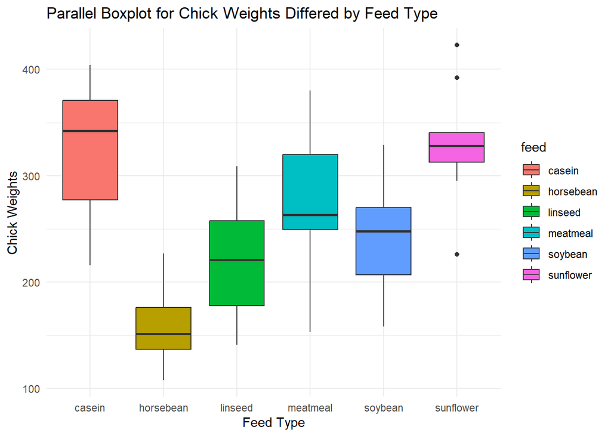

```r
# calling the ggplot library
library("ggplot2")

# using geom_boxplot to plot a box plot
ggplot(chickwts, aes(x = feed, y = weight,  fill = feed))+
  geom_boxplot()+
  theme_minimal()+
  xlab("Feed Type")+
  ylab("Chick Weights")+
  ggtitle("Parallel Boxplot for Chick Weights Differed by Feed Type")
```

5. Instead of boxplots, create a violin plot and “strip chart” with jitters. Use the functions geom_violin and geom_jitter in the same plot. You will have to play with the values of alpha in the geom_violin function (relating to the transparency of the “violin”) and width in the geom_jitter function. As before, make sure color is an aesthetic tied to the feed type, and add a title to the plot.

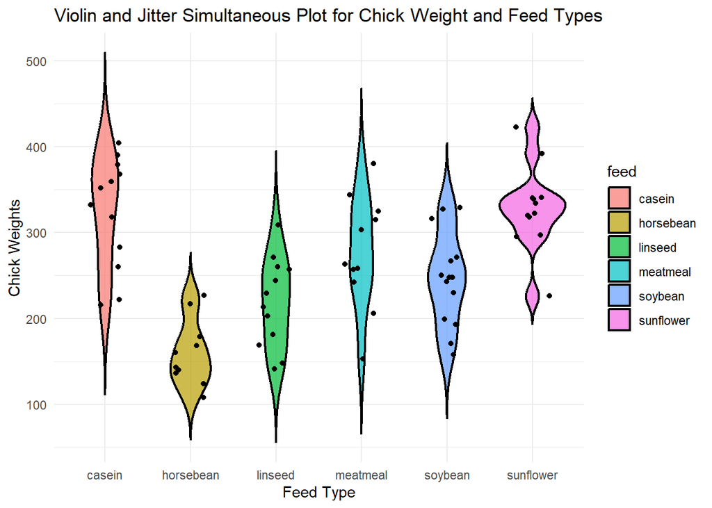

```r
# using geom_violin to plot a box plot

ggplot(chickwts, aes(x  = feed, y = weight, fill = feed))+
  geom_violin(alpha = 0.7, linewidth = 0.8, colour = "black", scale = "count", trim=FALSE)+
  geom_jitter(height = 0, width = 0.2, show.legend = FALSE)+
  theme_minimal()+
  xlab("Feed Type")+
  ylab("Chick Weights")+
  ggtitle("Violin and Jitter Simultaneous Plot for Chick Weight and Feed Types")
```

6. Compare the set of boxplots to the set of violin plots. What are advantages of the boxplot over the violin plot? What are advantages of the violin plot over the boxplot?

**Ans** : The boxplot with the *chickwts* data shows the median (which is the black line in the boxes in the above plot), gives the minimum and maximum point in the data set using the lines extending vertically from the top and bottom of the boxes. The boxplot also shows the outliers in the *chickwts* data for the *sunflower* feed type (which are the 2 black dots above and 1 dot below the box). The boxplot can give hard values and percentiles of the *chickwts* data which is not possible to interpret in the violin plots.

The violin plot visualization gives more information on the density of the data around certain values such as for *sunflower* feed type in the above plot, it can be observed that more of the data points are clustered just above the 300 weight mark for the *sunflower* feed type and around 150 weight mark for the *horsebean* feed type. In some cases for *linseed* and *meatmeal* feed types, they have an almost evenly distributed data. This density information is not possible in the boxplots which can give us more information on how the data might be clustered along some y-axis. This would help us in delving deeper into the “why” of the density cluster for that specific group.